# **Assignment: Grammy Record of the Year Winners & Nominees**

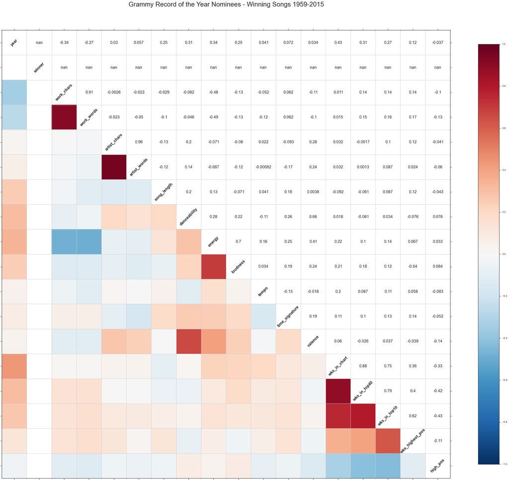

```python
everythingwin = everything[(everything['winner']==1)]
sns.corrplot(everythingwin, cmap='RdBu_r',)
plt.title('Grammy Record of the Year Nominees - Winning Songs 1959-2015')
sns.set_context(rc={"figure.figsize": (40, 40)})
```

In summary, the following have been observed:

1. Losing nominees - there is a stronger positive correlation between song energy and year of nomination (0.51) than can be seen with winning songs (0.34).

2. Losing songs have a positive correlation between the highest chart position attained and the number of characters in the song title (0.053), whereas winning songs have a negative correlation (-0.1).

3. The number of characters in a winning song's title is negatively correlated with the year of win (-0.34). For losing songs this is -0.18.

4. There appears to be a strong correlation between valence and energy amongst our nominees, with the highest number of nominees being in the high valence/high energy quadrant, followed closely by the low energy/low valence quadrant. However, winners proportionately less likely to come from the high-valence / high-energy quadrant.

5. Song energy tended to increase, peaking in the 1980's, and has now pulled back from those highs. However the central peak of our nominees' energy is less than that of the wider song market.

6. Valence has increased over the years and has generally been higher than the wider market, especially post-2000.

7. Nominated songs tend to be longer in length than the perceived industry "gold standard" of approximately 3 minutes. Song length across nominees appears to have typically declined since the 2000's.

8. Analysis of our song titles shows that pronouns are common, as are common words that are easy to pronounce and the use of shorter (rather than longer) words. Mentioning love or one of its variants (including "heart") could potentially help. Positive words were utilised more often than negative (e.g. beautiful vs lonesome).

9. Perhaps the most significant previously undiscovered correlation relates to that between song energy and the number of characters in a song title. When all nominees are considered as a pool we can see that this is -0.18. However, when we split the losers and winners out we can see that there are significant differences between the two groups (-0.11 losers; -0.48 winners). This could potentially be because shorter song titles get to the point - inferring energy? Compare this to the low-energy non-nominated "You be the anchor that keeps my feet on the ground, I'll be the wings that keeps your heart in the clouds" by Mayday Parade. This information for winners is charted pictorially below:

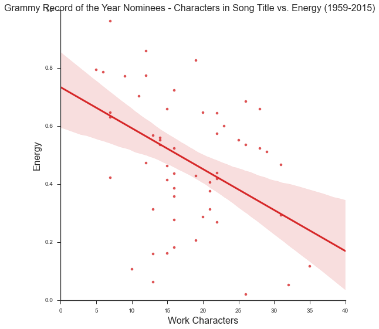

```python
chartchart = sns.lmplot("work_chars", "energy", data=everythingwin,
              color=newcolours[8], y_jitter=.25, size=8)
v=(0, 40, 0, 1)
plt.axis(v)
chartchart.set_axis_labels("Work Characters", "Energy")
chartchart.fig.suptitle('Grammy Record of the Year Nominees - Characters in Song Title vs. Energy (1959-2015)')
```

**Please refer to Appendix 2 which discusses Bob Marley, The Beach Boys and The Rolling Stones.**